# Obecná analýza letištní sítě

Petra Dundáček Božoňová

# Načtení knihoven

```r
library(dplyr) # knihovna pro zpracování dat (data.frame)
library(ggplot2) # knihovna pro vykreslování grafů
library(igraph) # knihovna pro analýzu sítí
library(rvest) # knihovna pro web scraping
rm(list=ls()) # vyčištění prostředí (odstranění všech objektů z aktuálního prostředí)
```

# Načtení dat

Celá práce je založena na dvou datasetech, které jsou včetně vysvětlivek dostupné na [tomto odkaze](https://openflights.org/data.php).

## Data o letech

Načtěme si hlavní soubor `routes.dat`.

```r
routes <- read.table("routes.dat", sep = ",")
colnames(routes) <- c("Airline", "AirlineID",
                      "SourceAirport", "SourceAirportID",
                      "DestinationAirport", "DestinationAirportID",
                      "Codeshare", "Stops", "Equipment")
```

a zobrazme si jeho prvních 200 řádků z celkových **67663**.

```r
if(output_type == "html") DT::datatable(routes %>% head(200))
```

|  | Airline | AirlineID | SourceAirport | SourceAirportID | DestinationAirport | DestinationAirportID | Codeshare | Stops | Equipment |
| --- | --- | --- | --- | --- | --- | --- | --- | --- | --- |
| 1 | 2B | 410 | AER | 2965 | KZN | 2990 |  | 0 | CR2 |
| 2 | 2B | 410 | ASF | 2966 | KZN | 2990 |  | 0 | CR2 |
| 3 | 2B | 410 | ASF | 2966 | MRV | 2962 |  | 0 | CR2 |
| 4 | 2B | 410 | CEK | 2968 | KZN | 2990 |  | 0 | CR2 |
| 5 | 2B | 410 | CEK | 2968 | OVB | 4078 |  | 0 | CR2 |
| 6 | 2B | 410 | DME | 4029 | KZN | 2990 |  | 0 | CR2 |
| 7 | 2B | 410 | DME | 4029 | NBC | 6969 |  | 0 | CR2 |
| 8 | 2B | 410 | DME | 4029 | TGK | \N |  | 0 | CR2 |
| 9 | 2B | 410 | DME | 4029 | UUA | 6160 |  | 0 | CR2 |
| 10 | 2B | 410 | EGO | 6156 | KGD | 2952 |  | 0 | CR2 |

[output cut: 190 more lines]

Vzhledem k dalšímu zpracování knihovnou `igraph` vybereme jako první dva sloupce kód výchozího a cílového letiště, tj. dva sloupce, které určují hrany ve studovaných grafech.

```r
routes <- routes %>% select(SourceAirport, DestinationAirport, Airline, Codeshare)
if(output_type == "html") DT::datatable(routes %>% head(200))
```

|  | SourceAirport | DestinationAirport | Airline | Codeshare |
| --- | --- | --- | --- | --- |
| 1 | AER | KZN | 2B |  |
| 2 | ASF | KZN | 2B |  |
| 3 | ASF | MRV | 2B |  |
| 4 | CEK | KZN | 2B |  |
| 5 | CEK | OVB | 2B |  |
| 6 | DME | KZN | 2B |  |
| 7 | DME | NBC | 2B |  |
| 8 | DME | TGK | 2B |  |
| 9 | DME | UUA | 2B |  |
| 10 | EGO | KGD | 2B |  |

[output cut: 190 more lines]

## Data o letištích

Nyní si načtěme pomocný soubor `airports.dat`.

```r
airports <- read.table("airports.dat", sep = ",", encoding = "UTF-8")
colnames(airports) <- c("AirportID", "Name", "City", "Country", "IATA", "ICAO",
                        "Latitude", "Longitude", "Altitude",
                        "Timezone", "DST", "Tz", "Type", "Source")
```

a zobrazme si jeho prvních 200 řádků z celkových **7698**.

```r
if(output_type == "html") DT::datatable(airports %>% head(200))
```

|  | AirportID | Name | City | Country | IATA | ICAO | Latitude | Longitude | Altitude | Timezone | DST | Tz | Type | Source |
| --- | --- | --- | --- | --- | --- | --- | --- | --- | --- | --- | --- | --- | --- | --- |
| 1 | 1 | Goroka Airport | Goroka | Papua New Guinea | GKA | AYGA | -6.081689834590001 | 145.391998291 | 5282 | 10 | U | Pacific/Port_Moresby | airport | OurAirports |
| 2 | 2 | Madang Airport | Madang | Papua New Guinea | MAG | AYMD | -5.20707988739 | 145.789001465 | 20 | 10 | U | Pacific/Port_Moresby | airport | OurAirports |
| 3 | 3 | Mount Hagen Kagamuga Airport | Mount Hagen | Papua New Guinea | HGU | AYMH | -5.826789855957031 | 144.2960052490234 | 5388 | 10 | U | Pacific/Port_Moresby | airport | OurAirports |
| 4 | 4 | Nadzab Airport | Nadzab | Papua New Guinea | LAE | AYNZ | -6.569803 | 146.725977 | 239 | 10 | U | Pacific/Port_Moresby | airport | OurAirports |
| 5 | 5 | Port Moresby Jacksons International Airport | Port Moresby | Papua New Guinea | POM | AYPY | -9.443380355834961 | 147.2200012207031 | 146 | 10 | U | Pacific/Port_Moresby | airport | OurAirports |
| 6 | 6 | Wewak International Airport | Wewak | Papua New Guinea | WWK | AYWK | -3.58383011818 | 143.669006348 | 19 | 10 | U | Pacific/Port_Moresby | airport | OurAirports |
| 7 | 7 | Narsarsuaq Airport | Narssarssuaq | Greenland | UAK | BGBW | 61.1604995728 | -45.4259986877 | 112 | -3 | E | America/Godthab | airport | OurAirports |
| 8 | 8 | Godthaab / Nuuk Airport | Godthaab | Greenland | GOH | BGGH | 64.19090271 | -51.6781005859 | 283 | -3 | E | America/Godthab | airport | OurAirports |
| 9 | 9 | Kangerlussuaq Airport | Sondrestrom | Greenland | SFJ | BGSF | 67.0122218992 | -50.7116031647 | 165 | -3 | E | America/Godthab | airport | OurAirports |
| 10 | 10 | Thule Air Base | Thule | Greenland | THU | BGTL | 76.5311965942 | -68.7032012939 | 251 | -4 | E | America/Thule | airport | OurAirports |

[output cut: 190 more lines]

Z tohoto datasetu si ponecháme pouze 6 sloupců:

- `Name` (název letiště)
- `City` (nejbližší město k místu letiště)
- `Country` (stát, ve kterém je umístěno letiště)
- `IATA` (IATA kód letiště)
- `Latitude` (zeměpisná šířka umíštění letiště ve stupních)
- `Longitude` (zeměpisná délka umíštění letiště ve stupních)

Klíčové pro další analýzu jsou přitom sloupce `Country` a `IATA`.

```r
airports <- airports %>% select(Name, City, Country, IATA, Latitude, Longitude)
if(output_type == "html") DT::datatable(airports %>% head(200))
```

|  | Name | City | Country | IATA | Latitude | Longitude |
| --- | --- | --- | --- | --- | --- | --- |
| 1 | Goroka Airport | Goroka | Papua New Guinea | GKA | -6.081689834590001 | 145.391998291 |
| 2 | Madang Airport | Madang | Papua New Guinea | MAG | -5.20707988739 | 145.789001465 |
| 3 | Mount Hagen Kagamuga Airport | Mount Hagen | Papua New Guinea | HGU | -5.826789855957031 | 144.2960052490234 |
| 4 | Nadzab Airport | Nadzab | Papua New Guinea | LAE | -6.569803 | 146.725977 |
| 5 | Port Moresby Jacksons International Airport | Port Moresby | Papua New Guinea | POM | -9.443380355834961 | 147.2200012207031 |
| 6 | Wewak International Airport | Wewak | Papua New Guinea | WWK | -3.58383011818 | 143.669006348 |
| 7 | Narsarsuaq Airport | Narssarssuaq | Greenland | UAK | 61.1604995728 | -45.4259986877 |
| 8 | Godthaab / Nuuk Airport | Godthaab | Greenland | GOH | 64.19090271 | -51.6781005859 |
| 9 | Kangerlussuaq Airport | Sondrestrom | Greenland | SFJ | 67.0122218992 | -50.7116031647 |
| 10 | Thule Air Base | Thule | Greenland | THU | 76.5311965942 | -68.7032012939 |

[output cut: 190 more lines]

```r
g <- graph_from_data_frame(routes, directed = FALSE)
```

# Vytvoření výchozích `igraph` objektů

Vytvoříme si výchozí grafy a vypíšeme si jejich počet uzlů a hran.

```r
graphFull <- graph_from_data_frame(routes, directed = FALSE)
cat("Graf má", gorder(graphFull), "uzlů a", gsize(graphFull), "hran.")
```

```
## Graf má 3425 uzlů a 67663 hran.
```

```r
graphSimple <- simplify(graphFull,
                        remove.multiple = TRUE,
                        remove.loops = TRUE)
cat("Graf má", gorder(graphSimple), "uzlů a", gsize(graphSimple), "hran.")
```

```
## Graf má 3425 uzlů a 19256 hran.
```

Počet hran tak klesl z **67663** na **19256**.

# Míry centrality

## Degree Centrality

```r
degreeGraphFull <- degree(graphFull, loops = FALSE)
degreeGraphSimple <- degree(graphSimple)
```

Vypišme 20 nejvýznamnějších letišť dle Degree Centrality.

```r
top20degreeGraphFull <- sort(degreeGraphFull, decreasing = TRUE)[1:20]
top20degreeGraphFull
```

```
##  ATL  ORD  PEK  LHR  CDG  LAX  FRA  DFW  JFK  AMS  PVG  SIN  BCN  ICN  DEN  MIA
## 1826 1108 1069 1051 1041  990  990  936  911  903  825  820  783  740  735  734
##  MUC  IST  HKG  DXB
##  728  719  710  710
```

```r
top20degreeGraphSimple <- sort(degreeGraphSimple, decreasing = TRUE)[1:20]
top20degreeGraphSimple
```

```
## AMS FRA CDG IST ATL PEK ORD MUC DME DXB DFW LHR DEN IAH LGW BCN JFK FCO MAD PVG
## 248 244 240 236 217 207 206 192 190 188 188 172 170 169 165 163 162 162 159 154
```

Pokud porovnáme 20 uzlů s nejvyšší hodnotou najdeme 15 z nich v obou seznamech. Zobrazme si, která letiště to jsou a která jsou jen v prvním, resp. v druhém seznamu.

```r
x <- names(top20degreeGraphFull)
y <- names(top20degreeGraphSimple)
# letiště v obou seznamech
x[x %in% y]
```

```
##  [1] "ATL" "ORD" "PEK" "LHR" "CDG" "FRA" "DFW" "JFK" "AMS" "PVG" "BCN" "DEN"
## [13] "MUC" "IST" "DXB"
```

```r
# letiště v top20degreeGraphFull, ale ne v top20degreeGraphSimple
x[!(x %in% y)]
```

```
## [1] "LAX" "SIN" "ICN" "MIA" "HKG"
```

```r
# letiště v top20degreeGraphSimple, ale ne v top20degreeGraphFull
knitr::kable(airports[match(y[!(y %in% x)], airports$IATA), c(1, 4)], row.names=FALSE)
```

| Name | IATA |
| --- | --- |
| Domodedovo International Airport | DME |
| George Bush Intercontinental Houston Airport | IAH |
| London Gatwick Airport | LGW |
| Leonardo da Vinci–Fiumicino Airport | FCO |
| Adolfo Suárez Madrid–Barajas Airport | MAD |

Nakonec určeme poměr Degree Centrality grafu s ponechanými multihranami s Degree Centrality grafu s odstraněnými multihranami a vypišme 20 nejvýznamnějších letišť dle tohoto poměru.

```r
round(sort(degreeGraphFull/degreeGraphSimple, decreasing = TRUE)[1:20], 3)
```

```
##    HTN    ATL    SCY    DCY    KMS    ABY    ENH    PHC    CEI    HGH    UDR
## 12.000  8.415  8.000  8.000  8.000  8.000  8.000  8.000  7.333  7.028  7.000
##    TAO    LGK    BJM    LAX    TNA    SIN    XIY    KHG    XMN
##  6.963  6.800  6.750  6.644  6.585  6.560  6.547  6.500  6.472
```

## Closeness Centrality

Vypišme 20 nejvýznamnějších letišť dle Closeness Centrality.

```r
closenessGraphSimple <- closeness(graphSimple)
round(sort(closenessGraphSimple, decreasing = TRUE)[1:20], 3)
```

```
##   SPB   SSB   BLD   GCW   CKX   TKJ   DUT   BFI   ERS   ESD   FRD   MPA   NDU
## 1.000 1.000 1.000 1.000 1.000 1.000 0.333 0.333 0.333 0.250 0.250 0.250 0.250
##   AKB   IKO   KQA   CLM   OND   GEA   LIF
## 0.200 0.200 0.200 0.200 0.200 0.111 0.067
```

Podívejme se na velikost jednotlivých komponent grafu.

```r
components(graphSimple)$csize
```

```
## [1] 3397    2    4    2    4    2    4   10
```

Je zřejmé, že největší komponenta grafu zahrnuje převážnou část uzlů (**3397** ze 3425).

Nyní určeme největší komponentu grafu.

```r
gLargestComponentSimple <- largest_component(graphSimple)
```

Nakonec vypišme 20 nejvýznamnějších letišť největší komponenty grafu dle Closeness Centrality.

```r
closenessLargestComponentSimple <- closeness(gLargestComponentSimple)
sort(closenessLargestComponentSimple, decreasing = TRUE)[1:20]
```

```
##          FRA          CDG          LHR          AMS          DXB          LAX
## 0.0001183292 0.0001176056 0.0001170001 0.0001157407 0.0001156337 0.0001144951
##          JFK          YYZ          IST          ORD          PEK          MUC
## 0.0001138822 0.0001125619 0.0001119570 0.0001117818 0.0001115698 0.0001114579
##          FCO          NRT          EWR          DOH          ICN          ZRH
## 0.0001108647 0.0001107174 0.0001104850 0.0001103022 0.0001099747 0.0001095890
##          MAD          IAH
## 0.0001094212 0.0001090869
```

## Harmonic Centrality

Vypišme 20 nejvýznamnějších letišť dle Harmonic Centrality.

```r
harmonicGraphSimple <- harmonic_centrality(graphSimple)
sort(harmonicGraphSimple, decreasing = TRUE)[1:20]
```

```
##      FRA      CDG      AMS      LHR      DXB      IST      JFK      PEK
## 1550.988 1543.088 1524.655 1511.738 1502.064 1482.073 1472.471 1467.664
##      LAX      MUC      ORD      YYZ      FCO      MAD      EWR      ICN
## 1462.071 1459.930 1452.771 1446.112 1440.730 1431.014 1425.638 1425.324
##      DOH      ATL      IAH      NRT
## 1422.005 1421.898 1421.731 1419.564
```

Seznamy 20 nejvýznamnějších letišť dle Closeness Centralit pro největší komponentu grafu a dle Harmonic Centrality se shodují v 19 letištích, přičemž umístění (pořadí) letišť z obou seznamů dle těchto metrik jsou srovnatelná. Podívejme se na tato umístění.

```r
namesTop20CC <- names(sort(closenessLargestComponentSimple, decreasing = TRUE)[1:20])
namesTop20HC <- names(sort(harmonicGraphSimple, decreasing = TRUE)[1:20])
namesTop20CCHC <- sort(unique(c(namesTop20CC,namesTop20HC)))

tableTop20CCHC <- matrix(c(rank(-closenessLargestComponentSimple)[namesTop20CCHC],
                           rank(-harmonicGraphSimple)[namesTop20CCHC]), nrow = 2, byrow = 2)
colnames(tableTop20CCHC) <- namesTop20CCHC
rownames(tableTop20CCHC) <- c("closenessLargestComponentSimple", "harmonicGraphSimple")
tableTop20CCHC
```

```
##                                 AMS ATL CDG DOH DXB EWR FCO FRA IAH ICN IST JFK
## closenessLargestComponentSimple   4  24   2  16   5  15  13   1  20  17   9   7
## harmonicGraphSimple               3  18   2  17   5  15  13   1  19  16   6   7
##                                 LAX LHR MAD MUC NRT ORD PEK YYZ ZRH
## closenessLargestComponentSimple   6   3  19  12  14  10  11   8  18
## harmonicGraphSimple               9   4  14  10  20  11   8  12  22
```

## Betweenness Centrality

Vypišme 20 nejvýznamnějších letišť největší komponenty grafu dle Betweenness Centrality.

```r
betweennessLargestComponentSimple <- betweenness(gLargestComponentSimple)
sort(betweennessLargestComponentSimple, decreasing = TRUE)[1:20]
```

```
##      ANC      LAX      CDG      DXB      FRA      PEK      AMS      SEA
## 424761.4 382128.9 362955.2 331029.2 299371.2 290484.6 288686.6 281919.2
##      ORD      YYZ      IST      GRU      LHR      NRT      SYD      BNE
## 280935.8 249941.3 244590.3 236655.3 218052.6 210582.6 191420.4 186488.5
##      SIN      DME      ATL      DFW
## 182541.0 172057.2 170130.3 169187.6
```

Nyní každé hraně největší komponenty grafy přidělme váhu ve výši převrácené hodnoty počtu hran, resp. multihran mezi příslušnými uzly. Takto definovaný graf (dále `gLargestCompSimpWeighted`) je potřeba zkonstruovat od počátku z výchozího `graphFull`. Funkci `simplify()` využijeme nejen k odstranění multihran, ale také k nasčítání jejich počtu (proto nastavíme výchozí atribut váhy hrany `weight` na jedničku).

```r
gLargestCompSimpWeighted <- graphFull
E(gLargestCompSimpWeighted)$weight <- 1
gLargestCompSimpWeighted <- largest_component(simplify(gLargestCompSimpWeighted))
E(gLargestCompSimpWeighted)$weight <- 1/E(gLargestCompSimpWeighted)$weight
```

Nyní určeme 20 nejvýznamnějších letišť `gLargestCompSimpWeighted` dle Betweenness Centrality.

```r
betweennessLargestCompSimpWeighted <- betweenness(gLargestCompSimpWeighted)
sort(betweennessLargestCompSimpWeighted, decreasing = TRUE)[1:20]
```

```
##       LHR       LAX       ATL       JFK       SIN       ORD       SEA       ANC
## 1419981.2  982227.3  980803.2  883780.1  685903.7  540771.3  539033.6  505992.2
##       MIA       CDG       BNE       NRT       PEK       GRU       BKK       DME
##  466612.7  399798.7  362774.8  352305.5  335414.2  334696.2  285722.5  261866.1
##       SYD       FRA       PVG       YYZ
##  244927.2  239675.4  229833.4  220880.9
```

Nyní se zaměřme na letiště *Anchorage*, které je z pohledu obou variant Betweenness Centrality velmi úspěšné. Nejprve se podívejme na souhrn jednotlivých metrik pro toto letiště.

```r
ANCmetrics <- data.frame(
  metrika = c("`degreeGraphSimple`", "`degreeGraphFull`",
              "`closenessLargestComponentSimple`", "`harmonicGraphSimple`",
              "`betweennessLargestComponentSimple`", "`betweennessLargestCompSimpWeighted`"),
  hodnota = c(degreeGraphSimple["ANC"], degreeGraphFull["ANC"],
              closenessLargestComponentSimple["ANC"], harmonicGraphSimple["ANC"],
              betweennessLargestComponentSimple["ANC"], betweennessLargestCompSimpWeighted["ANC"]),
  pořadí = c(rank(-degreeGraphSimple)["ANC"], rank(-degreeGraphFull)["ANC"],
             rank(-closenessLargestComponentSimple)["ANC"], rank(-harmonicGraphSimple)["ANC"],
             rank(-betweennessLargestComponentSimple)["ANC"], rank(-betweennessLargestCompSimpWeighted)["ANC"])
)
ANCmetrics$hodnota <- format(ANCmetrics$hodnota, digits = 4)
knitr::kable(ANCmetrics)
```

| metrika | hodnota | pořadí |
| --- | --- | --- |
| `degreeGraphSimple` | 3.400e+01 | 289.5 |
| `degreeGraphFull` | 1.180e+02 | 276.0 |
| `closenessLargestComponentSimple` | 8.806e-05 | 348.0 |
| `harmonicGraphSimple` | 1.105e+03 | 336.0 |
| `betweennessLargestComponentSimple` | 4.248e+05 | 1.0 |
| `betweennessLargestCompSimpWeighted` | 5.060e+05 | 8.0 |

Dále se podívejme na letiště přímo sousedící s letištěm *Anchorage*. Nejprve si připravme doplňující informace o letištích v USA ze stránky na Wikipedii, viz [List of airports in the United States](https://en.wikipedia.org/wiki/List_of_airports_in_the_United_States) a [List of airports in Alaska](https://en.wikipedia.org/wiki/List_of_airports_in_Alaska).

```r
USAirports <- read_html("https://en.wikipedia.org/wiki/List_of_airports_in_the_United_States") %>%
  html_table() %>% .[[2]]
selectedRows <- which(USAirports$FAA=="")
nRepetitions <- c(selectedRows[-1], nrow(USAirports) + 1) - selectedRows - 1
USAirports <- cbind(data.frame(State = rep(USAirports$City[selectedRows], nRepetitions),
                               USAirports[-selectedRows,]))
AlaskaAirports <- read_html("https://en.wikipedia.org/wiki/List_of_airports_in_Alaska") %>%
  html_table() %>% .[[1]] %>% filter(`City served` != "")
AlaskaAirports$State <- rep("ALASKA", nrow(AlaskaAirports))
AlaskaAirports$IATA <- gsub("\\[1\\]", "", AlaskaAirports$IATA)
AlaskaAirports <- AlaskaAirports[c(ncol(AlaskaAirports), 1:(ncol(AlaskaAirports)-1))]
colnames(AlaskaAirports) <- colnames(USAirports)
USAirports <- unique(rbind(USAirports, AlaskaAirports))
if(output_type == "html") DT::datatable(USAirports)
```

|  | State | City | FAA | IATA | ICAO | Airport | Role | Enplanements |
| --- | --- | --- | --- | --- | --- | --- | --- | --- |
| 1 | ALABAMA | Birmingham | BHM | BHM | KBHM | Birmingham–Shuttlesworth International Airport | P-S | 1,081,328 |
| 2 | ALABAMA | Dothan | DHN | DHN | KDHN | Dothan Regional Airport | P-N | 37,047 |
| 3 | ALABAMA | Huntsville | HSV | HSV | KHSV | Huntsville International Airport (Carl T. Jones Field) | P-S | 459,759 |
| 4 | ALABAMA | Mobile | MOB | MOB | KMOB | Mobile Regional Airport | P-N | 236,007 |
| 5 | ALABAMA | Montgomery | MGM | MGM | KMGM | Montgomery Regional Airport (Dannelly Field) | P-N | 129,033 |
| 6 | ALASKA | Anchorage | MRI | MRI | PAMR | Merrill Field | P-N | 22,907 |
| 7 | ALASKA | Anchorage | ANC | ANC | PANC | Ted Stevens Anchorage International Airport | P-M | 2,184,959 |
| 8 | ALASKA | Bethel | BET | BET | PABE | Bethel Airport (also see Bethel Seaplane Base) | P-N | 105,877 |
| 9 | ALASKA | Cordova | CDV | CDV | PACV | Merle K. (Mudhole) Smith Airport | P-N | 15,058 |
| 10 | ALASKA | Deadhorse | SCC | SCC | PASC | Deadhorse Airport (Prudhoe Bay Airport) | P-N | 64,245 |

[output cut: 848 more lines]

Nyní se podívejme na `degreeGraphSimple` letišť přímo sousedících s letištěm *Anchorage*.

```r
ANCneighbors <- neighbors(graphSimple, "ANC")$name
dfANCneighbors <- airports %>% select(IATA, Name) %>% filter(IATA %in% ANCneighbors)
dfANCneighbors$State <- USAirports$State[match(dfANCneighbors$IATA, USAirports$IATA)]
dfANCneighbors$degreeGraphSimple <- degreeGraphSimple[dfANCneighbors$IATA]
knitr::kable(dfANCneighbors %>% arrange(degreeGraphSimple, IATA))
```

| IATA | Name | State | degreeGraphSimple |
| --- | --- | --- | --- |
| ADK | Adak Airport | ALASKA | 1 |
| ENA | Kenai Municipal Airport | ALASKA | 1 |
| HOM | Homer Airport | ALASKA | 1 |
| ILI | Iliamna Airport | ALASKA | 1 |
| SDP | Sand Point Airport | ALASKA | 1 |
| VDZ | Valdez Pioneer Field | ALASKA | 1 |
| CDV | Merle K (Mudhole) Smith Airport | ALASKA | 2 |
| DLG | Dillingham Airport | ALASKA | 2 |
| SNP | St Paul Island Airport | ALASKA | 2 |
| STG | St George Airport | ALASKA | 2 |
| CDB | Cold Bay Airport | ALASKA | 4 |
| KSM | St Mary’s Airport | ALASKA | 4 |
| MCG | McGrath Airport | ALASKA | 5 |
| SCC | Deadhorse Airport | ALASKA | 5 |
| UNK | Unalakleet Airport | ALASKA | 6 |
| BRW | Wiley Post Will Rogers Memorial Airport | ALASKA | 7 |
| ADQ | Kodiak Airport | ALASKA | 8 |
| ANI | Aniak Airport | ALASKA | 9 |
| AKN | King Salmon Airport | ALASKA | 10 |
| OTZ | Ralph Wien Memorial Airport | ALASKA | 14 |
| JNU | Juneau International Airport | ALASKA | 16 |
| OME | Nome Airport | ALASKA | 16 |
| FAI | Fairbanks International Airport | ALASKA | 24 |
| BET | Bethel Airport | ALASKA | 29 |
| HNL | Daniel K Inouye International Airport | HAWAII | 52 |
| PDX | Portland International Airport | OREGON | 58 |
| PHX | Phoenix Sky Harbor International Airport | ARIZONA | 91 |
| SLC | Salt Lake City International Airport | UTAH | 92 |
| SEA | Seattle Tacoma International Airport | WASHINGTON | 94 |
| MSP | Minneapolis-St Paul International/Wold-Chamberlain Airport | MINNESOTA | 131 |
| LAS | McCarran International Airport | NEVADA | 133 |
| LAX | Los Angeles International Airport | CALIFORNIA | 149 |
| DEN | Denver International Airport | COLORADO | 170 |
| ORD | Chicago O’Hare International Airport | ILLINOIS | 206 |

Dále zobrazme podgraf letiště *Anchorage* a jeho sousedů.

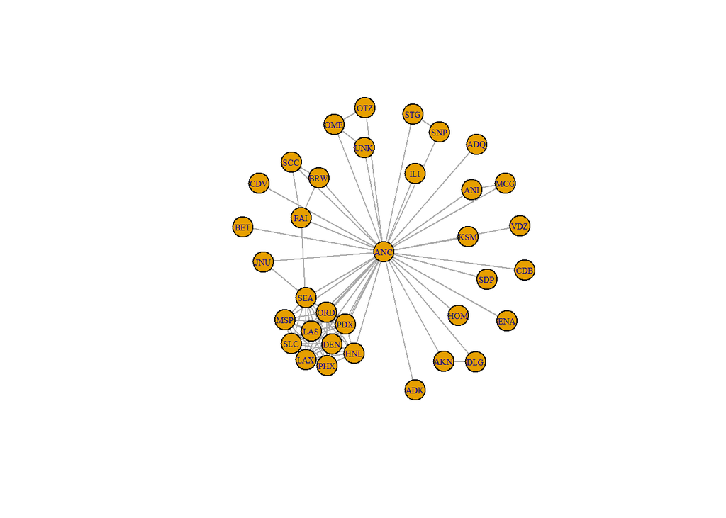

```r
graphANC <- induced_subgraph(graphSimple, c("ANC", neighbors(graphSimple, "ANC")$name))
plot(graphANC, vertex.label.cex = 0.5)
```

A nakonec se podívejme, co se stane s hlavní komponentou grafu, jestliže z ní letiště Anchorage odebereme.

```r
gSimpleWithoutANC <- delete_vertices(gLargestComponentSimple, "ANC")
gComponentsSimpleWithoutANC <- components(gSimpleWithoutANC)
gComponentsSimpleWithoutANC$csize
```

```
##  [1] 3359   12    1    1    1    1   13    4    1    2    1
```

Rozpadne se na 11 komponent grafu, přičemž většina uzlů bude součástí největší z nich. Ostatních 10 menších komponent si zobrazme.

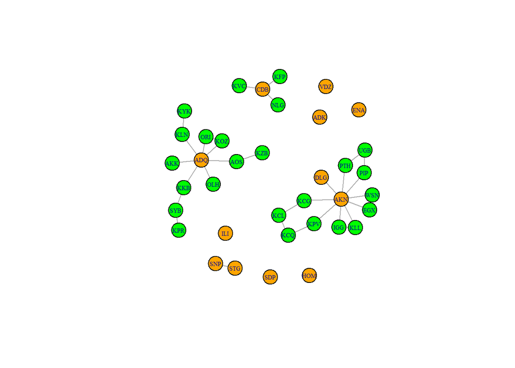

```r
gComponentsSimpleWithoutANCreduced <-
  delete_vertices(gLargestComponentSimple,
                  c(V(largest_component(gSimpleWithoutANC))$name, "ANC"))
vertex.color <- rep("green", gorder(gComponentsSimpleWithoutANCreduced))
vertex.color[V(gComponentsSimpleWithoutANCreduced)$name %in% V(graphANC)$name] <- "orange"
plot(gComponentsSimpleWithoutANCreduced, vertex.label.cex = 0.5, vertex.color = vertex.color)
```

Podívejme se, v jakém státě letiště z těchto 10 menších komponent leží.

```r
setNames(USAirports$State[match(V(gComponentsSimpleWithoutANCreduced)$name, USAirports$IATA)],
         V(gComponentsSimpleWithoutANCreduced)$name)
```

```
##      ADQ      AOS      KKB      KLN      KOZ      SYB      ENA      HOM
## "ALASKA" "ALASKA" "ALASKA" "ALASKA" "ALASKA" "ALASKA" "ALASKA" "ALASKA"
##      VDZ      AKK      OLH      ORI      ADK      AKN      CDB      DLG
## "ALASKA" "ALASKA" "ALASKA" "ALASKA" "ALASKA" "ALASKA" "ALASKA" "ALASKA"
##      SDP      SNP      STG      EGX      IGG      KCG      KCL      KCQ
## "ALASKA" "ALASKA" "ALASKA" "ALASKA" "ALASKA" "ALASKA" "ALASKA" "ALASKA"
##      KFP      KLL      KPV      KVC      NLG      PIP      PTH      UGB
## "ALASKA" "ALASKA" "ALASKA" "ALASKA" "ALASKA" "ALASKA" "ALASKA" "ALASKA"
##      WSN      ILI      KZB      KYK      KPR
## "ALASKA" "ALASKA" "ALASKA" "ALASKA" "ALASKA"
```

## Eigenvector Centrality

Vypišme 20 nejvýznamnějších letišť největší komponenty grafu dle Eigenvector Centrality.

```r
EVCLargestComponentSimple <- eigen_centrality(gLargestComponentSimple)$vector
sort(EVCLargestComponentSimple, decreasing = TRUE)[1:20]
```

```
##       AMS       FRA       CDG       MUC       FCO       LHR       IST       BCN
## 1.0000000 0.9912705 0.9499177 0.8848377 0.8122343 0.8109811 0.7705396 0.7633363
##       ZRH       MAD       BRU       DUB       DUS       MAN       LGW       VIE
## 0.7506447 0.7325383 0.7324287 0.6910965 0.6855653 0.6837200 0.6821968 0.6792567
##       CPH       JFK       MXP       DXB
## 0.6516729 0.6344571 0.6283609 0.6183532
```

Zobrazme si také největší kliku největší komponenty grafu.

```r
largest_cliques(gLargestComponentSimple)
```

```
## [[1]]
## + 24/3397 vertices, named, from 11d6dae:
##  [1] MKE ORD MCI IAH DEN PHL YYZ BOS MSP DTW CLT DFW FLL ATL STL EWR LAX SFO MCO
## [20] PHX LAS CLE MSY BWI
##
## [[2]]
## + 24/3397 vertices, named, from 11d6dae:
##  [1] MKE ORD MCI IAH DEN PHL YYZ BOS MSP DTW CLT DFW FLL ATL STL EWR LAX SFO MCO
## [20] PHX LAS CLE MSY DCA
```

A podívejme se na umístění letišť z první zjištěné největší kliky v pořadí dle výše uvedené Eigenvector Centrality.

```r
setNames(match((largest_cliques(gLargestComponentSimple)[[1]])$name,
               names(sort(EVCLargestComponentSimple, decreasing = TRUE))),
               (largest_cliques(gLargestComponentSimple)[[1]])$name)
```

```
## MKE ORD MCI IAH DEN PHL YYZ BOS MSP DTW CLT DFW FLL ATL STL EWR LAX SFO MCO PHX
## 259  28 225  64 114  53  29  80 118  90  88  74 138  38 187  26  49  82 120 152
## LAS CLE MSY BWI
## 104 196 220 160
```

# Degree Distribution

Nejdříve si ukážeme výsledky pro Degree Distribution uzlů letecké dopravní sítě bez multihran.

```r
table(degreeGraphSimple)
```

```
## degreeGraphSimple
##   1   2   3   4   5   6   7   8   9  10  11  12  13  14  15  16  17  18  19  20
## 768 744 407 237 163 111  84  83  79  47  43  36  32  18  23  18  19  26  26  22
##  21  22  23  24  25  26  27  28  29  30  31  32  33  34  35  36  37  38  39  40
##  19  12  16   7   8  16   3   7  13  15   7  14  10   6  10   2   9  14   7   4
##  41  42  43  44  45  46  47  48  49  50  51  52  53  54  55  56  57  58  59  60
##  13   3   4   4   5   2   8   5   6   6   5   4   1   3   7   3   7   4   3   1
##  61  62  63  64  65  66  67  68  69  70  72  73  74  75  76  77  78  79  80  81
##   4   3   2   3   2   2   3   2   3   2   4   2   3   2   1   2   3   1   2   4
##  82  83  85  86  87  89  90  91  92  93  94  95  96  97  98 101 102 103 104 105
##   1   3   4   3   1   3   2   2   2   2   2   2   2   1   2   1   1   3   2   2
## 108 110 111 112 113 117 118 122 123 124 125 127 131 133 134 135 137 138 139 141
##   1   1   1   1   2   1   1   2   2   1   1   2   1   2   1   1   1   1   1   1
## 144 147 148 149 150 153 154 159 162 163 165 169 170 172 188 190 192 206 207 217
##   2   2   1   1   1   3   1   1   2   1   1   1   1   1   2   1   1   1   1   1
## 236 240 244 248
##   1   1   1   1
```

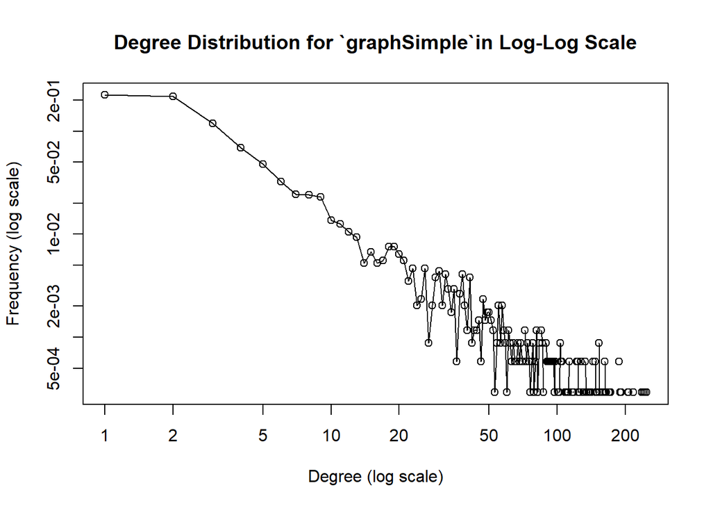

```r
plot(degree_distribution(graphSimple, cumulative = FALSE)[-1],
     log = "xy",
     xlab = "Degree (log scale)",
     ylab = "Frequency (log scale)",
     main = "Degree Distribution for `graphSimple`in Log-Log Scale",
     type = "o")
```

A nakonec si ukážeme výsledky pro Degree Distribution uzlů letecké dopravní sítě s multihranami.

```r
table(degreeGraphFull)
```

```
## degreeGraphFull
##    1    2    3    4    5    6    7    8    9   10   11   12   13   14   15   16
##   21  681   44  539   49  323   33  207   27  147   24  121   16   86   13   69
##   17   18   19   20   21   22   23   24   25   26   27   28   29   30   31   32
##   10   52   11   47   11   42    6   29    7   32    8   26    8   24    5   24
##   33   34   35   36   37   38   39   40   41   42   43   44   45   46   47   48
##    8   20    6   26    3   10    3   16    6   14    4    9    3    9    2   13
##   49   50   51   52   54   55   56   57   58   60   61   62   63   64   66   67
##    2    5    5    9    6    4   10    5   12    7    3    7    4    4   10    4
##   68   69   70   71   72   73   74   75   76   77   78   79   80   81   82   83
##    5    6    7    5    5    1    4    3    6    4    5    2    3    5    3    4
##   84   85   86   87   88   89   90   91   92   93   94   95   97   98   99  100
##    4    3    7    1    3    2    7    3    4    1    4    4    3    3    2    3
##  101  102  103  104  105  106  107  108  110  111  112  114  116  117  118  119
##    2    3    2    4    2    4    1    2    2    2    3    3    4    1    3    2
```

[output cut: 26 more lines]

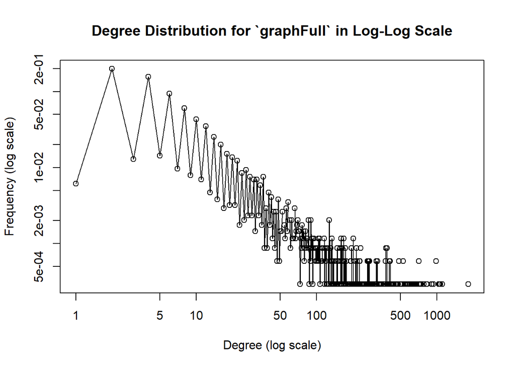

```r
plot(degree_distribution(graphFull, cumulative = FALSE)[-1],
     log = "xy",
     xlab = "Degree (log scale)",
     ylab = "Frequency (log scale)",
     main = "Degree Distribution for `graphFull` in Log-Log Scale",
     type = "o")
```

# Shlukovací koeficient

Nejprve si zobrazíme globální transitivity za celou síť.

```r
transitivity(graphSimple, type = "global")
```

```
## [1] 0.248303
```